# Tracking Global Healtcare

## Line Plot: UHC Access and Life Expectancy Over Time

The line plot comparing UHC access for RMNCH interventions with life expectancy sheds light on how improvements in healthcare access correlate with better health outcomes. As countries increase access to essential healthcare services, we often see a rise in life expectancy, especially among women and children. This highlights the transformative power of UHC interventions. For a more comprehensive understanding of the drivers behind these trends, let’s now explore the relationship between a country’s wealth and its healthcare access.

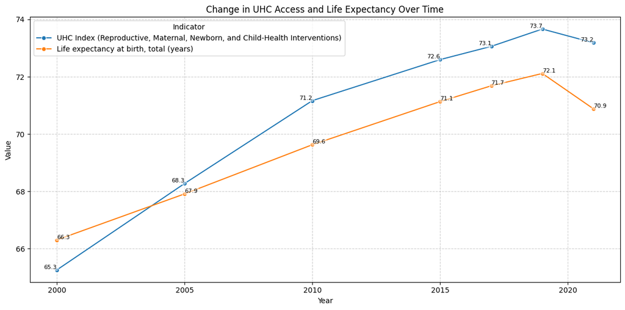

```python
# 3. Line plot
plt.figure(figsize=(12, 6))
sns.lineplot(data=melted_df, x='year', y='Value', hue='Indicator', marker='o', errorbar=None)

# Annotate with values
agg_df = melted_df.groupby(['year', 'Indicator'])['Value'].mean().reset_index()
for _, row in agg_df.iterrows():
    plt.text(
        x=row['year'],
        y=row['Value'],
        s=f"{row['Value']:.1f}",
        fontsize=8,
        ha='right' if row['Indicator'] == 'UHC Index (Reproductive, Maternal, Newborn, and Child-Health Interventions)' else 'left',
        va='bottom',
        bbox=dict(facecolor='white', alpha=0.5, edgecolor='none', boxstyle="round,pad=0.2")
    )

plt.title('Change in UHC Access and Life Expectancy Over Time')
plt.xlabel('Year')
plt.ylabel('Value')
plt.legend(title='Indicator')
plt.grid(True, linestyle='--', alpha=0.6)  # Adding gridlines for better visibility
plt.tight_layout()

# Save the plot as a PNG file
plt.savefig('uhc_life_expectancy_over_time.png', dpi=300)

# Show the plot
plt.show()
```

As UHC Index improves globally, life expectancy at birth rises in tandem, reflecting a clear upward trend. Enhanced RMNCH access ensures better maternal and child survival rates, reducing preventable deaths and fostering healthier populations, which directly contributes to longer lifespans, as noted by WHO. Factors like increased skilled birth attendance and antenatal care, particularly in low-income regions, drive these gains by addressing critical health risks early in life.

## Scatter Plot: GDP vs. Healthcare Access with Trendline

The scatter plot compares GDP per capita with RMNCH healthcare access across countries, with each point representing a nation’s economic status and healthcare access level. A trendline shows that wealthier nations tend to offer better healthcare services. However, there are notable exceptions where lower-income countries have made impressive strides despite financial limitations. This demonstrates that factors beyond income, such as policy decisions and international support, also play a significant role in improving healthcare access. To see which countries have made the most progress, we now turn to the bar chart.

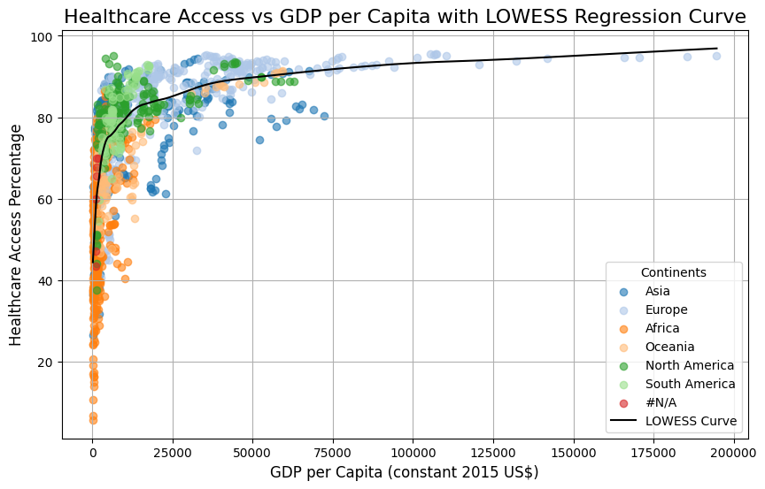

```python
# Set up the color palette for the continents
continent_colors = sns.color_palette("tab20", len(merged_pd['Continent'].unique()))  # 'tab20' palette can handle up to 20 unique continents

# Map each country to its corresponding continent color
continent_color_map = {continent: color for continent, color in zip(merged_pd['Continent'].unique(), continent_colors)}

# Scatter Plot with LOWESS Regression Curve - Healthcare Access vs GDP
plt.figure(figsize=(10, 6))

# Create a scatter plot with color based on the continent
for continent in merged_pd['Continent'].unique():
    continent_data = merged_pd[merged_pd['Continent'] == continent]
    plt.scatter(continent_data['GDP per capita (constant 2015 US$)'],
                continent_data['Healthcare_Access_Percentage'],
                color=continent_color_map[continent],
                label=continent, alpha=0.6)

# Apply LOWESS smoothing
lowess = sm.nonparametric.lowess
lowess_result = lowess(merged_pd['Healthcare_Access_Percentage'],
                       merged_pd['GDP per capita (constant 2015 US$)'],
                       frac=0.3)  # frac controls the smoothness of the curve

# Plot the LOWESS curve
plt.plot(lowess_result[:, 0], lowess_result[:, 1], color='black', label="LOWESS Curve")

# Customizing the plot
plt.title('Healthcare Access vs GDP per Capita with LOWESS Regression Curve', fontsize=16)
plt.xlabel('GDP per Capita (constant 2015 US$)', fontsize=12)
plt.ylabel('Healthcare Access Percentage', fontsize=12)
plt.legend(title="Continents")
plt.grid(True)

# Save the plot as a PNG file
plt.savefig('healthcare_vs_gdp_lowess_regression_by_continent.png', dpi=300, bbox_inches='tight')

# Show the plot (optional, will appear in Jupyter Notebook if running in it)
plt.show()
```

The scatter plot illustrates that richer countries generally have higher Universal Health Coverage indices with access often exceeding 90% in nations like those in Europe and North America. The trendline confirms this correlation, reflecting greater investments in healthcare infrastructure and skilled personnel in wealthier economies. However, outliers such as Rwanda and Ethiopia, low-income African countries with GDP per capita below $1,000, stand out with RMNCH access rates approaching 80% or higher, defying their economic constraints. According to WHO and UNICEF, these countries have leveraged community health worker programs, international aid, and policy reforms to prioritize maternal and child health, achieving significant gains

## Bar Chart: Top 10 Countries with Largest Improvements in Women’s Healthcare Access

The bar chart showcases the top 10 countries with the largest improvements in women’s RMNCH healthcare access over recent years. This visualization highlights the nations that have made the greatest strides in improving healthcare access for women and children, regardless of their economic status. The countries featured here provide valuable lessons in how policy reforms, community health programs, and increased funding can lead to significant improvements. These success stories remind us that achieving better healthcare access is possible through concerted efforts and smart strategies.

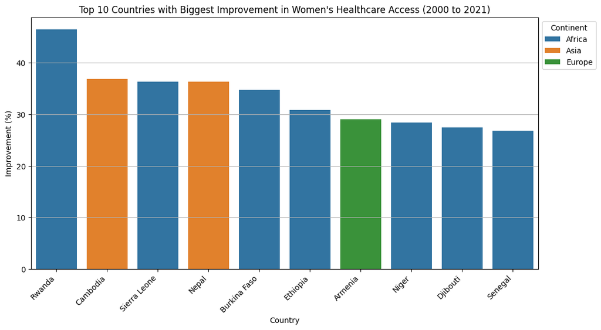

```python
# 1. Bar Chart: Women with Healthcare Access by Country (Latest Year)
latest_year = merged_df['year'].max()
earliest_year = merged_df['year'].min()

# Filter data for latest and earliest years
latest_data = merged_df.filter(pl.col('year') == latest_year)
earliest_data = merged_df.filter(pl.col('year') == earliest_year)

# Join latest and earliest data by country
compare_df = latest_data.join(
    earliest_data.select(['Country', 'obs_value']).rename({'obs_value': 'obs_value_earliest'}),
    on='Country', how='inner'
)

# Calculate improvement, top 10 countries
compare_df = compare_df.with_columns(
    (pl.col('obs_value') - pl.col('obs_value_earliest')).alias('Improvement')
)

top10_improvements = compare_df.sort('Improvement', descending=True).head(10)

top10_pd = top10_improvements.to_pandas()
year_range = f'{earliest_year} to {latest_year}'

# Plotting bar chart
plt.figure(figsize=(12, 6))
sns.barplot(data=top10_pd, x='Country', y='Improvement', hue='Continent')
plt.title(f'Top 10 Countries with Biggest Improvement in Women\'s Healthcare Access ({year_range})')
plt.xlabel('Country')
plt.ylabel('Improvement (%)')
plt.xticks(rotation=45, ha='right')
plt.grid(True, axis='y')

# Legend
plt.legend(title='Continent', loc='upper left', bbox_to_anchor=(1, 1))
plt.show()
```

## Conclusion:

This report illustartes the global landscape of UHC for RMNCH interventions, using visualizations to show the disparities in healthcare access, the progress made by individual countries, and the factors driving these changes. While some countries have made significant improvements, much work remains to be done, particularly in low-income regions. By continuing to invest in healthcare systems, particularly in underserved countries, we can move closer to achieving SDG 3: ensuring healthy lives and promoting well-being for all. The visualizations presented in this report underscore the need for action, collaboration, and continued efforts to provide essential healthcare to every woman and child.